# Simul

Pablo Andrés Guzmán Taller R y Rmarkdown

Ago 2022

Hola mundo

## Librerías

```r
library(tidyverse)
library(openxlsx)
```

Consulte la viñeta del paquete openxlsx [aquí](https://cran.r-project.org/web/packages/openxlsx/vignettes/Introduction.html).

## Modelo Poisson

La distribución Poisson tiene como función de (masa de) probabilidad:

$$f(y\ ; \lambda) = \dfrac{\lambda^y \times e^{-\lambda}}{y!} \ , \quad \text{ con } y = \{0,1,2,3,\ldots\} \quad { \text{ y } \quad \lambda > 0 }$$
La media y varianza de una variable aleatoria Poisson es:

$$\text{E}(Y) = \lambda \quad \text{ y } \quad \text{Var}(Y) = \lambda$$

### Ejemplo 1: Modelo Poisson

Suponga que una variable aleatoria $Y$ sigue un modelo de probabilidad Poisson con $\lambda = 4$. Calcular la probabilidad de que $Y \leq 2$.

**Solución**

$$\begin{eqnarray*}
P(Y \leq 2) = \sum_{y = 0}^2 f(y) & = & f(0) + f(1) + f(2) \\
& = & \dfrac{4^0 \times e^{-4}}{0!} + \dfrac{4^1 \times e^{-4}}{1!} + \dfrac{4^2 \times e^{-4}}{2!}
\end{eqnarray*}$$

## Modelo Binomial Negativo

Este modelo tiene dos parametrizaciones o expresiones. Aquí presentamos aquella comunmente usada en el contexto de modelos lineales generalizados:

$$f(y\,;k\,; \mu) = \dfrac{\Gamma(y+k)}{\Gamma(y+1) \times \Gamma(k)} \times \left(\dfrac{k}{\mu + k}\right)^k\times\left(1-\dfrac{k}{\mu+k}\right)^y$$

con $y = \{0,1,2, \ldots\}$; $k > 0$; $\mu = \{0,1,2, \ldots\}$; y $\Gamma(\cdot)$ es la función Gamma, la cual esta definida para enteros positivos como $\Gamma(a) = (a-1)!$. La media y varianza de una binomial negativa es:

$$\text{E}(Y) = \mu \quad \text{ y } \quad \text{Var}(Y) = \mu + \dfrac{\mu^2}{k}$$
Observe que:

- Si $k \rightarrow \infty$ entonces $\dfrac{\mu^2}{k} \rightarrow 0$ y por ende $\text{Var}(Y) \rightarrow \mu$ y la Binomial Negativa $\rightarrow$ Poisson.
- Si $k \rightarrow 0$ entonces $\dfrac{\mu^2}{k} \rightarrow \infty$ y por ende $\text{Var}(Y) > \mu$. Aquí existiría **sobredispersión** y la Binomial Negativa sería diferente a la Poisson.

Note entonces que el modelo Poisson se podría considerar como un caso especial de la Binomial Negativa cuando el parámetro $k$ es muy grande relativo a $\mu^2$.

En **R** el comando `dnbinom` entrega la probabilidad para el modelo binomial negativo, y la parametrización presentada arriba coincide directamente con los argumentos `mu` (= $\mu$) y `size` (= $k$).

**Ejemplo**

Considere una v.a $y$ Binomial Negativa con $\text{E}(Y) = \mu = 4$ y el parámetro $k$ de sobredispersión igual a $k = 1000$, de tal forma que $\text{Var}(Y) = 4 + \dfrac{16}{1000} = 4.016$. Observe que la varianza es practicamente la misma varianza que tendría una Poisson.

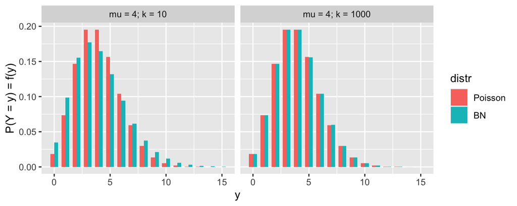